# Part II - Bike Sharing Data Exploration

## by Michael Muuwo Mutie

## Investigation Overview

The goal of this exploration was to establish what features contributed to the duration taked in bike rides. The features that were used in this exploration include user_type, age and gender. I created the age feature by subtracting the user's year of birth from 2022. A summary of the insights obtained is as listed below.

- our data set has more than thrice the number of male compared to female while a smaller fraction identified as other gender.
- Majority of the users were subscribers as compared to cutomers.
- most of the riders are currently aged between 30 to 40 years
- The younger riders took more time riding as compared to the older riders.
- we note that walk in customers took longer rides than registered subscribers.
- for those who identify as 'other gender', we have a spike of longer rides between age 50 to 60

## Dataset Overview

> This data set includes information about individual rides made in a bike-sharing system covering the greater San Francisco Bay area. The data set was downloaded from Udacity classroom. It contained 183412 rows and 16 columns before the exploration.

## (Visualization 1)

> There is a huge number of male riders compared to female riders as displayed below. There is also a small fraction of riders identified as 'other gender'

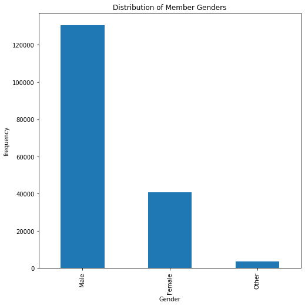

## (Visualization 2)

> Most of the riders are currently aged between 30 to 40 years.

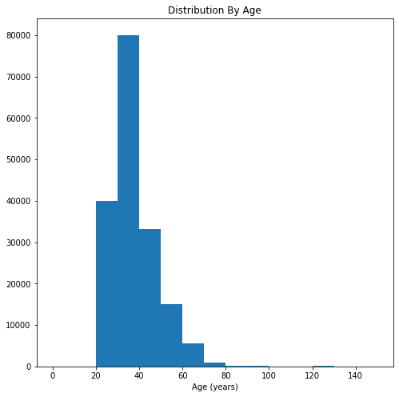

## (Visualization 3)

younger riders are taking longer rides compared to older riders.

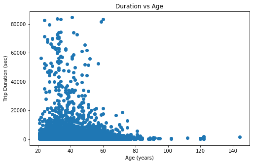